# Ford GoBike System Data

## by Qing

> This data set includes information about individual rides made in a bike-sharing system covering the greater San Francisco Bay area.

```python
# import all packages and set plots to be embedded inline
import numpy as np
import pandas as pd
import matplotlib.pyplot as plt
import seaborn as sb
import os
import requests
from zipfile import ZipFile

%matplotlib inline
```

## Gathering Data

### download the zip file

```python
# create a list of interesting date
dates_of_interest = list(range(201906, 201909))
```

```python
# Retrieve zip files from the server and combine included csv files into one csv file
for date in dates_of_interest:
    filename = f'{date}-baywheels-tripdata.csv.zip'
    url = f'https://s3.amazonaws.com/baywheels-data/{filename}'
    r = requests.get(url)

    with open(filename, 'wb') as f:
        f.write(r.content)
```

```python
# unzip all .zip files
# https://stackoverflow.com/questions/10377998/how-can-i-iterate-over-files-in-a-given-directory
for filename in os.listdir('.'):
    if filename.endswith('.zip'):
        with ZipFile(filename, 'r') as z:
            z.extractall()
```

```python
# combine data of all csv in one dataframe and save it as csv file in local
# https://www.freecodecamp.org/news/how-to-combine-multiple-csv-files-with-8-lines-of-code-265183e0854/
to_combined_data = []
for filename in os.listdir('.'):
    if filename.endswith('tripdata.csv'):
        to_combined_data.append(pd.read_csv(filename))

combined_data = pd.concat(to_combined_data)
combined_data.to_csv( 'ford_gobike_summer.csv', index=False, encoding='utf-8')
```

> Load in dataset and describe its properties through the questions below. Try and motivate your exploration goals through this section.

### Assessing Data

```python
#load dataset as dataframe
bike = pd.read_csv('ford_gobike_summer.csv')
```

```python
#check the loaded dataset
bike.head()
```

|  | duration_sec | start_time | end_time | start_station_id | start_station_name | start_station_latitude | start_station_longitude | end_station_id | end_station_name | end_station_latitude | end_station_longitude | bike_id | user_type | bike_share_for_all_trip | rental_access_method |
| --- | --- | --- | --- | --- | --- | --- | --- | --- | --- | --- | --- | --- | --- | --- | --- |
| 0 | 81695 | 2019-06-30 18:16:09.7730 | 2019-07-01 16:57:45.5920 | 109.0 | 17th St at Valencia St | 37.763316 | -122.421904 | 56.0 | Koshland Park | 37.773414 | -122.427317 | 1502 | Subscriber | No | NaN |
| 1 | 74260 | 2019-06-30 18:09:55.8300 | 2019-07-01 14:47:36.6810 | 50.0 | 2nd St at Townsend St | 37.780526 | -122.390288 | 101.0 | 15th St at Potrero Ave | 37.767079 | -122.407359 | 2526 | Customer | No | NaN |
| 2 | 59603 | 2019-06-30 15:40:31.0380 | 2019-07-01 08:13:54.3490 | 23.0 | The Embarcadero at Steuart St | 37.791464 | -122.391034 | 30.0 | San Francisco Caltrain (Townsend St at 4th St) | 37.776598 | -122.395282 | 2427 | Subscriber | No | NaN |
| 3 | 67932 | 2019-06-30 12:49:47.7810 | 2019-07-01 07:42:00.5430 | 169.0 | Bushrod Park | 37.846516 | -122.265304 | 248.0 | Telegraph Ave at Ashby Ave | 37.855956 | -122.259795 | 1261 | Customer | No | NaN |
| 4 | 48894 | 2019-06-30 17:21:00.0550 | 2019-07-01 06:55:54.9960 | 15.0 | San Francisco Ferry Building (Harry Bridges Pl... | 37.795392 | -122.394203 | 30.0 | San Francisco Caltrain (Townsend St at 4th St) | 37.776598 | -122.395282 | 1070 | Customer | No | NaN |

```python
#general information about the dataset
bike.info()
```

```
<class 'pandas.core.frame.DataFrame'>
RangeIndex: 660437 entries, 0 to 660436
Data columns (total 15 columns):
 #   Column                   Non-Null Count   Dtype
---  ------                   --------------   -----
 0   duration_sec             660437 non-null  int64
 1   start_time               660437 non-null  object
 2   end_time                 660437 non-null  object
 3   start_station_id         602390 non-null  float64
 4   start_station_name       602986 non-null  object
 5   start_station_latitude   660437 non-null  float64
 6   start_station_longitude  660437 non-null  float64
 7   end_station_id           600599 non-null  float64
 8   end_station_name         601149 non-null  object
 9   end_station_latitude     660437 non-null  float64
 10  end_station_longitude    660437 non-null  float64
 11  bike_id                  660437 non-null  int64
 12  user_type                660437 non-null  object
 13  bike_share_for_all_trip  568690 non-null  object
 14  rental_access_method     91747 non-null   object
dtypes: float64(6), int64(2), object(7)
memory usage: 75.6+ MB
```

```python
bike.describe()
```

|  | duration_sec | start_station_id | start_station_latitude | start_station_longitude | end_station_id | end_station_latitude | end_station_longitude | bike_id |
| --- | --- | --- | --- | --- | --- | --- | --- | --- |
| count | 660437.000000 | 602390.000000 | 660437.000000 | 660437.000000 | 600599.000000 | 660437.000000 | 660437.000000 | 660437.000000 |
| mean | 839.129908 | 141.366709 | 37.763927 | -122.349256 | 138.303199 | 37.764107 | -122.348682 | 68373.553590 |
| std | 1862.434090 | 118.745796 | 0.111195 | 0.174492 | 117.854793 | 0.111125 | 0.174114 | 185453.263799 |
| min | 60.000000 | 3.000000 | 37.279518 | -122.514299 | 3.000000 | 36.739538 | -122.514287 | 12.000000 |
| 25% | 375.000000 | 44.000000 | 37.769757 | -122.411901 | 43.000000 | 37.770030 | -122.411403 | 1260.000000 |
| 50% | 595.000000 | 100.000000 | 37.780526 | -122.398279 | 97.000000 | 37.780760 | -122.397437 | 2477.000000 |
| 75% | 925.000000 | 234.000000 | 37.795393 | -122.291415 | 223.000000 | 37.796248 | -122.293400 | 3670.000000 |
| max | 86217.000000 | 459.000000 | 45.510000 | -73.570000 | 459.000000 | 45.510000 | -73.570000 | 999422.000000 |

```python
#check nan values in start_station_id
bike.start_station_id.isnull().sum()
```

```
58047
```

```python
#check nan values in start_station_name
bike.start_station_name.isnull().sum()
```

```
57451
```

```python
#check nan values in end_station_id
bike.end_station_id.isnull().sum()
```

```
59838
```

```python
#check nan values in end_station_name
bike.end_station_name.isnull().sum()
```

```
59288
```

```python
# the value in bike_share_for_all_trip
bike.bike_share_for_all_trip.value_counts()
```

```
No     533129
Yes     35561
Name: bike_share_for_all_trip, dtype: int64
```

```python
#the value in rental_access_method
bike.rental_access_method.value_counts()
```

```
app        82832
clipper     8915
Name: rental_access_method, dtype: int64
```

```python
#user status
bike.user_type.value_counts()
```

```
Subscriber    537316
Customer      123121
Name: user_type, dtype: int64
```

```python
bike.start_station_id.value_counts()
```

```
67.0     15046
81.0     12238
15.0     11279
58.0     10544
21.0      9433
         ...
344.0        8
65.0         6
428.0        5
408.0        4
329.0        3
Name: start_station_id, Length: 380, dtype: int64
```

```python
#check duplicates
bike.duplicated().sum()
```

```
0
```

#### Quality

- missing values in start_station_id, start_station_name, end_station_id, end_station_name, bike_share_for_all_trip, rental_access_method
- erroneous data type in start_time, end_time(to datetime), start_station_id, end_station_id, bike_id (to string)

### What is the structure of your dataset?

> row: 660437 column:15

### What is/are the main feature(s) of interest in your dataset?

> time, station, duration, user type

### What features in the dataset do you think will help support your investigation into your feature(s) of interest?

> duration, time, user type

### Cleaning Data

```python
# make a copy
bike_clean = bike.copy()
```

```python
# drop columns
columns_to_drop = ['start_station_latitude', 'start_station_longitude',
                   'end_station_latitude', 'end_station_longitude']

bike_clean.drop(columns = columns_to_drop, inplace = True)
```

```python
#check the missing values in cleaned dataframe
bike_clean.info()
```

```
<class 'pandas.core.frame.DataFrame'>
RangeIndex: 660437 entries, 0 to 660436
Data columns (total 11 columns):
 #   Column                   Non-Null Count   Dtype
---  ------                   --------------   -----
 0   duration_sec             660437 non-null  int64
 1   start_time               660437 non-null  object
 2   end_time                 660437 non-null  object
 3   start_station_id         602390 non-null  float64
 4   start_station_name       602986 non-null  object
 5   end_station_id           600599 non-null  float64
 6   end_station_name         601149 non-null  object
 7   bike_id                  660437 non-null  int64
 8   user_type                660437 non-null  object
 9   bike_share_for_all_trip  568690 non-null  object
 10  rental_access_method     91747 non-null   object
dtypes: float64(2), int64(2), object(7)
memory usage: 55.4+ MB
```

```python
#convert data type
# https://stackoverflow.com/questions/32827169/python-reduce-precision-pandas-timestamp-dataframe
bike_clean['start_time'] = pd.to_datetime(bike_clean['start_time']).astype('datetime64[s]')
bike_clean['end_time'] = pd.to_datetime(bike_clean['end_time']).astype('datetime64[s]')
bike_clean['bike_id'] = bike_clean['bike_id'].astype('str')
bike_clean['start_station_id'] = bike_clean['start_station_id'].astype('str')
bike_clean['end_station_id'] = bike_clean['end_station_id'].astype('str')
```

```python
#confirm the data type
bike_clean.dtypes
```

```
duration_sec                        int64
start_time                 datetime64[ns]
end_time                   datetime64[ns]
start_station_id                   object
start_station_name                 object
end_station_id                     object
end_station_name                   object
bike_id                            object
user_type                          object
bike_share_for_all_trip            object
rental_access_method               object
dtype: object
```

```python
#create new columns for date and time seperately
#https://stackoverflow.com/questions/30405413/python-pandas-extract-year-from-datetime-dfyear-dfdate-year-is-not
bike_clean['date'] = bike_clean['start_time'].dt.date
bike_clean['time'] = bike_clean['start_time'].dt.time
```

```python
bike_clean.sample(10)
```

|  | duration_sec | start_time | end_time | start_station_id | start_station_name | end_station_id | end_station_name | bike_id | user_type | bike_share_for_all_trip | rental_access_method | date | time |
| --- | --- | --- | --- | --- | --- | --- | --- | --- | --- | --- | --- | --- | --- |
| 581542 | 621 | 2019-08-13 09:08:37 | 2019-08-13 09:18:59 | 365.0 | Turk St at Fillmore St | 3.0 | Powell St BART Station (Market St at 4th St) | 1486 | Subscriber | No | NaN | 2019-08-13 | 09:08:37 |
| 617976 | 3007 | 2019-08-07 16:23:59 | 2019-08-07 17:14:06 | 243.0 | Bancroft Way at College Ave | 240.0 | Haste St at Telegraph Ave | 84 | Customer | No | NaN | 2019-08-07 | 16:23:59 |
| 480397 | 430 | 2019-08-27 17:04:04 | 2019-08-27 17:11:14 | 3.0 | Powell St BART Station (Market St at 4th St) | 3.0 | Powell St BART Station (Market St at 4th St) | 9815 | Customer | No | NaN | 2019-08-27 | 17:04:04 |
| 25662 | 719 | 2019-06-26 16:37:27 | 2019-06-26 16:49:27 | 23.0 | The Embarcadero at Steuart St | 321.0 | 5th St at Folsom | 3306 | Subscriber | No | NaN | 2019-06-26 | 16:37:27 |
| 80373 | 357 | 2019-06-18 10:08:05 | 2019-06-18 10:14:02 | 27.0 | Beale St at Harrison St | 66.0 | 3rd St at Townsend St | 2262 | Subscriber | No | NaN | 2019-06-18 | 10:08:05 |
| 145788 | 1214 | 2019-06-07 14:49:23 | 2019-06-07 15:09:37 | 147.0 | 29th St at Tiffany Ave | 42.0 | San Francisco City Hall (Polk St at Grove St) | 3439 | Subscriber | No | NaN | 2019-06-07 | 14:49:23 |
| 323414 | 499 | 2019-07-08 18:12:44 | 2019-07-08 18:21:04 | 56.0 | Koshland Park | 53.0 | Grove St at Divisadero | 1433 | Subscriber | No | NaN | 2019-07-08 | 18:12:44 |
| 127067 | 512 | 2019-06-10 19:26:18 | 2019-06-10 19:34:50 | 67.0 | San Francisco Caltrain Station 2 (Townsend St... | 284.0 | Yerba Buena Center for the Arts (Howard St at ... | 3371 | Subscriber | No | NaN | 2019-06-10 | 19:26:18 |
| 191880 | 246 | 2019-07-31 22:46:43 | 2019-07-31 22:50:50 | 321.0 | 5th St at Folsom | 284.0 | Yerba Buena Center for the Arts (Howard St at ... | 3644 | Subscriber | No | NaN | 2019-07-31 | 22:46:43 |
| 415274 | 2620 | 2019-07-27 11:25:05 | 2019-07-27 12:08:46 | nan | NaN | nan | NaN | 892636 | Customer | NaN | app | 2019-07-27 | 11:25:05 |

```python
# save the cleaned dataset
bike_clean.to_csv('ford_gobike_summer_master.csv', index = False)
```

## Univariate Exploration

```python
# load the cleaned dataset
gobike = pd.read_csv('ford_gobike_summer_master.csv')
```

**1. How long are people riding these bikes?**

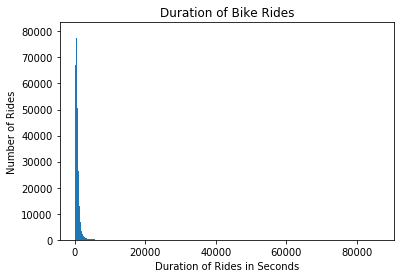

```python
#Visualizing the data in a histogram
duration_bins = np.arange(0, gobike['duration_sec'].max() + 100, 100)
plt.hist(data = gobike, x = 'duration_sec', bins = duration_bins);

plt.title('Duration of Bike Rides');
plt.xlabel('Duration of Rides in Seconds');
plt.ylabel('Number of Rides');
```

```python
np.log10(gobike.duration_sec.describe())
```

```
count    5.819831
mean     2.923829
std      3.270081
min      1.778151
25%      2.574031
50%      2.774517
75%      2.966142
max      4.935593
Name: duration_sec, dtype: float64
```

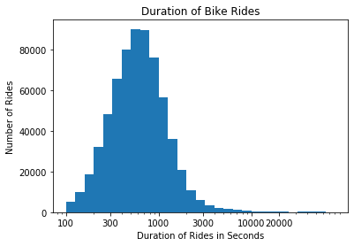

```python
# add log scaling to x axis
duration_bins = 10 ** np.arange(2, 5, 0.1)
plt.hist(data = gobike, x = 'duration_sec', bins = duration_bins);
# add logarithm to x axis
plt.xscale('log');
#set the tick location according to the location in plt.xscale('log')
ticks = [100, 300, 1000, 3000, 10000, 20000]
#set x ticks label
labels = ['{}'.format(v) for v in ticks]
plt.xticks(ticks, labels);
plt.xlabel('Duration of Rides in Seconds');
plt.ylabel('Number of Rides');
plt.title('Duration of Bike Rides');
```

**Exploration1**

- In this first analysis, we see a distribution of how long people are using these bikes in seconds. Due to some outliers on the high end extremely skewed the data. Then I add logarithm to x axis and the peak appears at somewhere between 500s and 1000s, which is between 8.33 min to 16.67 min.So that means people more tend to use gobike for a short ride.

**2. Number of Rides Per day**

I'm curious to see the distribution of rides changed over time.

```python
# filter dataset according to the each month
# https://stackoverflow.com/questions/22898824/filtering-pandas-dataframes-on-dates
june = gobike[(gobike.date >= '2019-06-01') & (gobike.date < '2019-07-01')].sort_values(by=['date'])
july = gobike[(gobike.date >= '2019-07-01') & (gobike.date < '2019-08-01')].sort_values(by=['date'])
august = gobike[(gobike.date >= '2019-08-01') & (gobike.date < '2019-09-01')].sort_values(by=['date'])
```

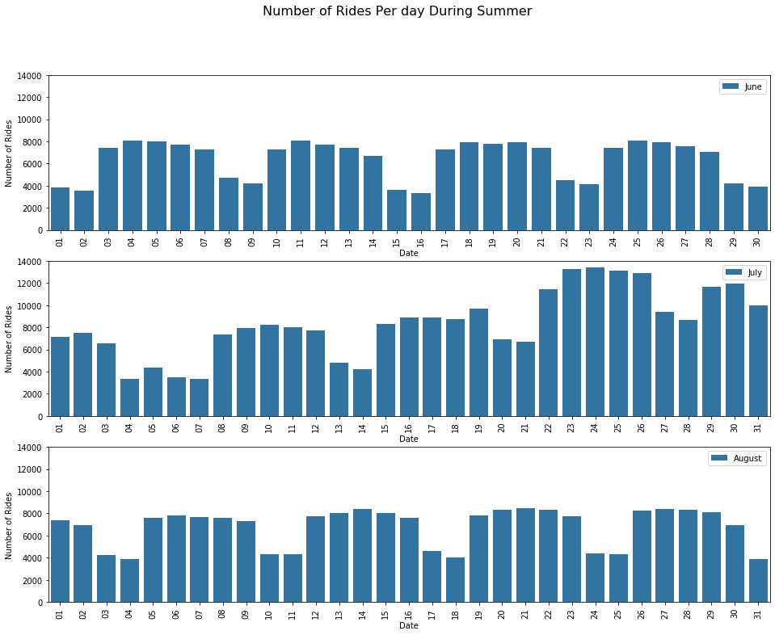

```python
#Visualizing the data with bar chart
def countplot(df, month):
    g = sb.countplot(data = df, x = 'date', color = base_color);
    plt.xlabel('Date')
    plt.ylabel('Number of Rides')
    plt.ylim(0, 14000)
    # get day from the xticks_lable(yyyy-mm-dd)
    #https://stackoverflow.com/questions/43595368/how-to-get-position-index-of-xtick-in-matplotlib-with-label-python-3-6-matpl/43597029
    new_labels = [x.get_text().split('-')[-1] for x in g.get_xticklabels()]
    # set new x tick labels
    g.set_xticklabels(new_labels)
    plt.legend([month])
    plt.xticks(rotation = 90);
    return

fig = plt.figure(figsize = (16, 12))
base_color = sb.color_palette()[0]
fig.suptitle('Number of Rides Per day During Summer', fontsize=16);
# for June
plt.subplot(3, 1, 1)
countplot(june, 'June');
# for July
plt.subplot(3, 1, 2)
countplot(july, 'July');
# for August
plt.subplot(3, 1, 3)
countplot(august, 'August');
```

**Exploration2**

- In this second analysis, we see a trend of number of rides per day for each month during summer. Except July, both June and August show the similar pattern of the trend, which is large number of rides during weekdays than weekends.Even, in the middle of weekdays show the highest usage of bike for June and August.So people more tend to use the gobike during weekdays and especially in the middle of weekdays. As for July, it might be caused by the vacation season or other possible reasons like public transpotation system breakdown.

**3. Number of Rides Per hour**

What are the high demand time per hour?

```python
gobike['start_hr'] =  gobike.time.apply(lambda x: x.split(':')[0])
gobike.head()
```

|  | duration_sec | start_time | end_time | start_station_id | start_station_name | end_station_id | end_station_name | bike_id | user_type | bike_share_for_all_trip | rental_access_method | date | time | start_hr |
| --- | --- | --- | --- | --- | --- | --- | --- | --- | --- | --- | --- | --- | --- | --- |
| 0 | 81695 | 2019-06-30 18:16:09 | 2019-07-01 16:57:45 | 109.0 | 17th St at Valencia St | 56.0 | Koshland Park | 1502 | Subscriber | No | NaN | 2019-06-30 | 18:16:09 | 18 |
| 1 | 74260 | 2019-06-30 18:09:55 | 2019-07-01 14:47:36 | 50.0 | 2nd St at Townsend St | 101.0 | 15th St at Potrero Ave | 2526 | Customer | No | NaN | 2019-06-30 | 18:09:55 | 18 |
| 2 | 59603 | 2019-06-30 15:40:31 | 2019-07-01 08:13:54 | 23.0 | The Embarcadero at Steuart St | 30.0 | San Francisco Caltrain (Townsend St at 4th St) | 2427 | Subscriber | No | NaN | 2019-06-30 | 15:40:31 | 15 |
| 3 | 67932 | 2019-06-30 12:49:47 | 2019-07-01 07:42:00 | 169.0 | Bushrod Park | 248.0 | Telegraph Ave at Ashby Ave | 1261 | Customer | No | NaN | 2019-06-30 | 12:49:47 | 12 |
| 4 | 48894 | 2019-06-30 17:21:00 | 2019-07-01 06:55:54 | 15.0 | San Francisco Ferry Building (Harry Bridges Pl... | 30.0 | San Francisco Caltrain (Townsend St at 4th St) | 1070 | Customer | No | NaN | 2019-06-30 | 17:21:00 | 17 |

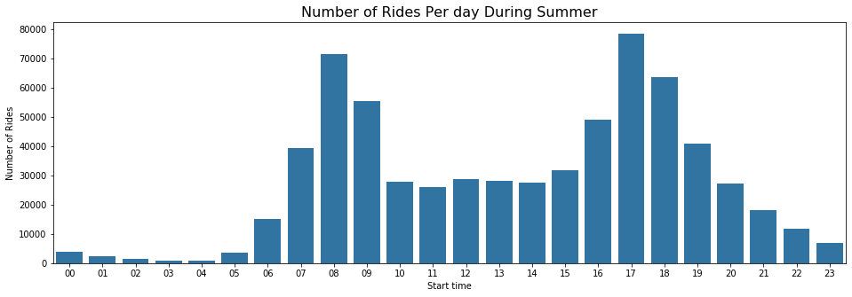

```python
plt.figure(figsize = (16,5))

sb.countplot(data = gobike, x = 'start_hr', color = base_color);
plt.xlabel('Start time')
plt.ylabel('Number of Rides')
plt.title('Number of Rides Per day During Summer', fontsize=16);
```

**Exploration3**

- In this third analysis, we see a trend of number of rides per hour for each day during summer. There large number of rides during day time, especially at 8:00 in the morning and 17:00 in the afternoon. People more tend to use the gobike at peak hour during day time.

**4. The Number of member using gobike**

```python
#Determining number of members and non-members
n_members = gobike.query('user_type == "Subscriber"').shape[0]
n_nonmembers = gobike.shape[0] - n_members
print(f'Member : {n_members} \nNon-member : {n_nonmembers}')
```

```
Member : 537316
Non-member : 123121
```

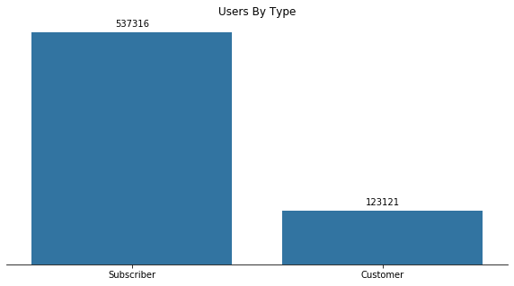

```python
#Visualizing number of members vs. non-members in bar chart
value_ct = gobike.user_type.value_counts()
fig = plt.figure(figsize = (10,5))
ax = sb.countplot(x = 'user_type', data = gobike, order=value_ct.index, color = base_color);
# https://stackoverflow.com/questions/2176424/hiding-axis-text-in-matplotlib-plots
# hide axis in plot
frame1 = plt.gca()
frame1.axes.get_yaxis().set_visible(False)
# https://seaborn.pydata.org/tutorial/aesthetics.html
# remove left spin
sb.despine(fig, left = True)

# add annotation on top of the bar
# https://stackoverflow.com/questions/39519609/annotate-bars-with-values-on-pandas-on-seaborn-factorplot-bar-plot

for p in ax.patches:
    ax.annotate("%d" % p.get_height(), (p.get_x() + p.get_width() / 2., p.get_height()+ 20000),
             ha='center', va='center')

ax.set_title("Users By Type");
ax.set_xlabel("");
```

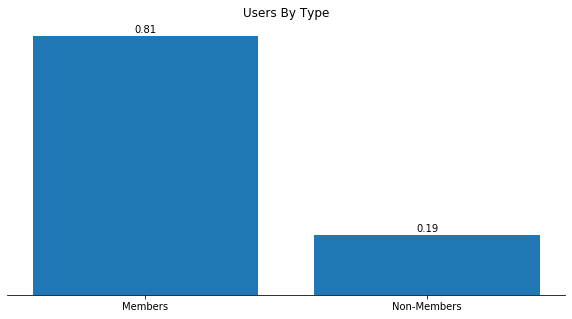

```python
member_percentage = n_members / gobike.shape[0]
nonmember_percentage = n_nonmembers / gobike.shape[0]
fig = plt.figure(figsize = (10,5))
# https://stackoverflow.com/questions/50560525/how-to-annotate-the-values-of-x-and-y-while-hovering-mouse-over-the-bar-graph
ax = plt.subplot()
plt.bar(x = ['Members', 'Non-Members'], height = [member_percentage, nonmember_percentage]);
# https://stackoverflow.com/questions/2176424/hiding-axis-text-in-matplotlib-plots
# hide axis in plot
frame1 = plt.gca()
frame1.axes.get_yaxis().set_visible(False)
# https://seaborn.pydata.org/tutorial/aesthetics.html
# remove left spin
sb.despine(fig, left = True)

# add annotation on top of the bar
# https://stackoverflow.com/questions/39519609/annotate-bars-with-values-on-pandas-on-seaborn-factorplot-bar-plot
for p in ax.patches:
    ax.annotate('{:.2f}'.format(p.get_height()), (p.get_x() + p.get_width() / 2., p.get_height() + 0.02), ha='center', va='center')
plt.title("Users By Type");
plt.xlabel("");
```

**Exploration4**

- In this fourth analysis, we see the number of member of gobike is much large than the non-member(4 times), 80% people are members.

**5. The top 10 popular srart station**

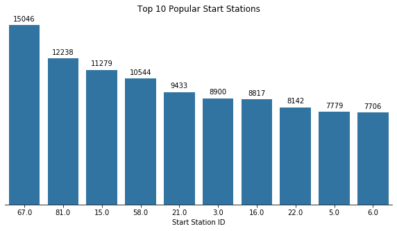

```python
value_ct = gobike.start_station_id.value_counts().iloc[:10]

fig = plt.figure(figsize = (10,5))
ax = sb.countplot(x = "start_station_id", data = gobike, order=value_ct.index, color = base_color);

# https://stackoverflow.com/questions/2176424/hiding-axis-text-in-matplotlib-plots
# hide axis in plot
frame1 = plt.gca()
frame1.axes.get_yaxis().set_visible(False)
# https://seaborn.pydata.org/tutorial/aesthetics.html
# remove left spin
sb.despine(fig, left = True)

# add annotation on top of the bar
# https://stackoverflow.com/questions/39519609/annotate-bars-with-values-on-pandas-on-seaborn-factorplot-bar-plot

for p in ax.patches:
    ax.annotate("%d" % p.get_height(), (p.get_x() + p.get_width() / 2., p.get_height()+500),
             ha='center', va='center')

ax.set_title("Top 10 Popular Start Stations");
ax.set_xlabel("Start Station ID");
```

```python
# get the corresponding start_station_name for each start_station_id
for x in value_ct.index:
    print(str(x) + ' : ' + str(gobike.query(f'start_station_id == "{x}"').start_station_name.drop_duplicates().values))
```

```
67.0 : ['San Francisco Caltrain Station 2  (Townsend St at 4th St)']
81.0 : ['Berry St at 4th St']
15.0 : ['San Francisco Ferry Building (Harry Bridges Plaza)']
58.0 : ['Market St at 10th St']
21.0 : ['Montgomery St BART Station (Market St at 2nd St)']
3.0 : ['Powell St BART Station (Market St at 4th St)']
16.0 : ['Steuart St at Market St']
22.0 : ['Howard St at Beale St']
5.0 : ['Powell St BART Station (Market St at 5th St)']
6.0 : ['The Embarcadero at Sansome St']
```

**Exploration5**

- In this fifth analysis, we see the top 10 popular start station and the most popular one is called San Francisco Caltrain Station 2. So maybe the company could pay more attention on the maintainance of those stations.

## Bivariate Exploration

> In this section, investigate relationships between pairs of variables in your data. Make sure the variables that you cover here have been introduced in some fashion in the previous section (univariate exploration).

**6. How long are people riding these bikes given the time of the day?**

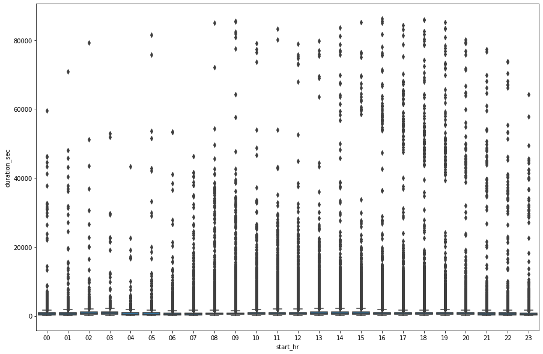

```python
# bar plot for start_hr vs. duration
plt.figure(figsize = (15,10))
sb.boxplot(x = 'start_hr', y = 'duration_sec', data = gobike, color = base_color);
```

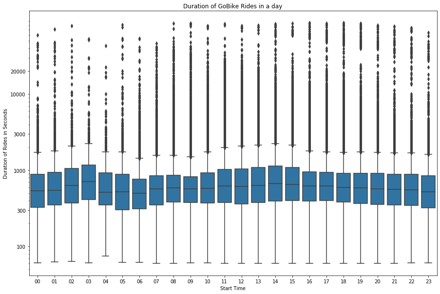

```python
# box plot for start_hr vs. duration
plt.figure(figsize = (15,10))
sb.boxplot(x = 'start_hr', y = 'duration_sec', data = gobike, color = base_color);
plt.yscale('log');
# set x ticks
ticks = [100, 300, 1000, 3000, 10000, 20000]
#set x ticks label
labels = ['{}'.format(v) for v in ticks]
plt.yticks(ticks, labels);
plt.xlabel('Start Time');
plt.ylabel('Duration of Rides in Seconds');
plt.title('Duration of GoBike Rides in a day');
```

**Exploration6**

- In this sixth analysis, we see the change of ride duration during a day.Due to some outliers on the high end, I add logarithm to x axis to zoom in the detail information. Most ride concentrate on the short ride range which we see above in the distribution of the ride duration. So no exception during the peak hour and no large fluctuation.

```python
june = gobike[(gobike.date >= '2019-06-01') & (gobike.date < '2019-07-01')].sort_values(by=['date'])
july = gobike[(gobike.date >= '2019-07-01') & (gobike.date < '2019-08-01')].sort_values(by=['date'])
august = gobike[(gobike.date >= '2019-08-01') & (gobike.date < '2019-09-01')].sort_values(by=['date'])
```

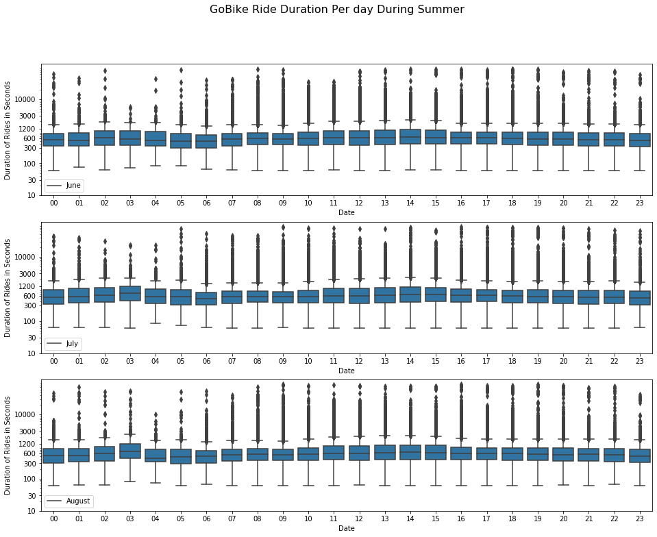

```python
def boxplot(df, month):
    g = sb.boxplot(data = df, x = 'start_hr', y = 'duration_sec', color = base_color);
    plt.xlabel('Date')
    plt.ylabel('Duration of Rides in Seconds')
    # get day from the xticks_lable(yyyy-mm-dd)
    #https://stackoverflow.com/questions/43595368/how-to-get-position-index-of-xtick-in-matplotlib-with-label-python-3-6-matpl/43597029
    new_labels = [x.get_text().split('-')[-1] for x in g.get_xticklabels()]
    # set new x tick labels
    g.set_xticklabels(new_labels)
    plt.legend([month])
    plt.yscale('log');
    # set x ticks
    ticks = [10, 30, 100, 300, 600, 1200, 3000, 10000]
    #set x ticks label
    labels = ['{}'.format(v) for v in ticks]
    plt.yticks(ticks, labels);
    return

fig = plt.figure(figsize = (16, 12))
fig.suptitle('GoBike Ride Duration Per day During Summer', fontsize=16);
# for June
plt.subplot(3, 1, 1)
boxplot(june, 'June');
# for July
plt.subplot(3, 1, 2)
boxplot(july, 'July');
# for August
plt.subplot(3, 1, 3)
boxplot(august, 'August');
```

**Exploration7**

- In this seventh analysis, we see the change of ride duration for each month during summer.Due to some outliers on the high end, I add logarithm to x axis to zoom in the detail information. Most ride concentrate on the short ride range (around 10min) which we see above in the distribution of the ride duration. So no exception during the peak hour and no large fluctuation.

**8. The number of member in top 10 popular station**

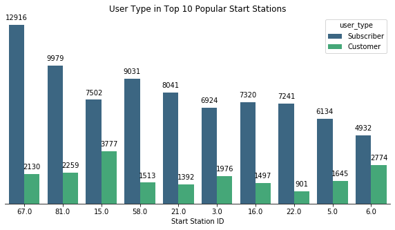

```python
value_ct = gobike.start_station_id.value_counts().iloc[:10]

fig = plt.figure(figsize = (10,5))
ax = sb.countplot(x = 'start_station_id', data = gobike, order=value_ct.index, palette = 'viridis', hue='user_type');

# https://stackoverflow.com/questions/2176424/hiding-axis-text-in-matplotlib-plots
# hide axis in plot
frame1 = plt.gca()
frame1.axes.get_yaxis().set_visible(False)
# https://seaborn.pydata.org/tutorial/aesthetics.html
# remove left spin
sb.despine(fig, left = True)

# add annotation on top of the bar
# https://stackoverflow.com/questions/39519609/annotate-bars-with-values-on-pandas-on-seaborn-factorplot-bar-plot

for p in ax.patches:
    ax.annotate("%d" % p.get_height(), (p.get_x() + p.get_width() / 2., p.get_height()+ 500),
             ha='center', va='center')

ax.set_title("User Type in Top 10 Popular Start Stations");
ax.set_xlabel("Start Station ID");
```

**Exploration8**

- In this eighth analysis, we observe that the most popular station (San Francisco Caltrain Station 2) has most member. In 3rd and 10th station called San Francisco Ferry Building (Harry Bridges Plaza) and The Embarcadero at Sansome St, the number of member are twice than that of non-member.The more attention of maintainance should be paid to those popular stations in order to provide constant good quality of service to our members.

**9. The top 10 frequent trip routes**

```python
#trip rounts combine the value in start station and end station
gobike['trip'] = gobike['start_station_id'].astype('str') + ' - ' + gobike['end_station_id'].astype('str')
gobike.head(10)
```

|  | duration_sec | start_time | end_time | start_station_id | start_station_name | end_station_id | end_station_name | bike_id | user_type | bike_share_for_all_trip | rental_access_method | date | time | start_hr | trip |
| --- | --- | --- | --- | --- | --- | --- | --- | --- | --- | --- | --- | --- | --- | --- | --- |
| 0 | 81695 | 2019-06-30 18:16:09 | 2019-07-01 16:57:45 | 109.0 | 17th St at Valencia St | 56.0 | Koshland Park | 1502 | Subscriber | No | NaN | 2019-06-30 | 18:16:09 | 18 | 109.0 - 56.0 |
| 1 | 74260 | 2019-06-30 18:09:55 | 2019-07-01 14:47:36 | 50.0 | 2nd St at Townsend St | 101.0 | 15th St at Potrero Ave | 2526 | Customer | No | NaN | 2019-06-30 | 18:09:55 | 18 | 50.0 - 101.0 |
| 2 | 59603 | 2019-06-30 15:40:31 | 2019-07-01 08:13:54 | 23.0 | The Embarcadero at Steuart St | 30.0 | San Francisco Caltrain (Townsend St at 4th St) | 2427 | Subscriber | No | NaN | 2019-06-30 | 15:40:31 | 15 | 23.0 - 30.0 |
| 3 | 67932 | 2019-06-30 12:49:47 | 2019-07-01 07:42:00 | 169.0 | Bushrod Park | 248.0 | Telegraph Ave at Ashby Ave | 1261 | Customer | No | NaN | 2019-06-30 | 12:49:47 | 12 | 169.0 - 248.0 |
| 4 | 48894 | 2019-06-30 17:21:00 | 2019-07-01 06:55:54 | 15.0 | San Francisco Ferry Building (Harry Bridges Pl... | 30.0 | San Francisco Caltrain (Townsend St at 4th St) | 1070 | Customer | No | NaN | 2019-06-30 | 17:21:00 | 17 | 15.0 - 30.0 |
| 5 | 47409 | 2019-06-30 16:47:22 | 2019-07-01 05:57:32 | 340.0 | Harmon St at Adeline St | 189.0 | Genoa St at 55th St | 2966 | Subscriber | No | NaN | 2019-06-30 | 16:47:22 | 16 | 340.0 - 189.0 |
| 6 | 37282 | 2019-06-30 14:31:39 | 2019-07-01 00:53:02 | 6.0 | The Embarcadero at Sansome St | 400.0 | Buchanan St at North Point St | 1980 | Customer | No | NaN | 2019-06-30 | 14:31:39 | 14 | 6.0 - 400.0 |
| 7 | 11105 | 2019-06-30 21:28:07 | 2019-07-01 00:33:12 | 377.0 | Fell St at Stanyan St | 380.0 | Masonic Ave at Turk St | 3515 | Subscriber | No | NaN | 2019-06-30 | 21:28:07 | 21 | 377.0 - 380.0 |
| 8 | 27656 | 2019-06-30 16:50:35 | 2019-07-01 00:31:32 | 24.0 | Spear St at Folsom St | 370.0 | Jones St at Post St | 1836 | Customer | No | NaN | 2019-06-30 | 16:50:35 | 16 | 24.0 - 370.0 |
| 9 | 1942 | 2019-06-30 23:48:21 | 2019-07-01 00:20:44 | 3.0 | Powell St BART Station (Market St at 4th St) | 16.0 | Steuart St at Market St | 1055 | Customer | No | NaN | 2019-06-30 | 23:48:21 | 23 | 3.0 - 16.0 |

```python
gobike.trip.value_counts().iloc[:11]
```

```
nan - nan        44447
15.0 - 6.0        1556
81.0 - 15.0       1534
15.0 - 81.0       1044
6.0 - 16.0        1005
343.0 - 21.0      1001
90.0 - 67.0        975
6.0 - 15.0         938
16.0 - 81.0        862
182.0 - 196.0      841
196.0 - 182.0      827
Name: trip, dtype: int64
```

[figure not shown]

```python
# heatmap for the top 10 frequent trips
trip_list = gobike.trip.value_counts().iloc[:11].keys()

trip = gobike[gobike['trip'].isin(trip_list)]
# https://pandas.pydata.org/pandas-docs/stable/reference/api/pandas.pivot_table.html
trip_pivot = trip.pivot_table(index='start_station_id', columns = 'end_station_id', values = 'time', aggfunc = 'count', fill_value = 0)

plt.subplots(figsize = (12,7))
# https://seaborn.pydata.org/generated/seaborn.heatmap.html
sb.heatmap(trip_pivot, annot = True, cmap = 'viridis_r', fmt='g', vmin = 1, vmax = 6000, mask= trip_pivot == 0)
plt.xlabel('Start Station ID',fontsize=13)
plt.ylabel('End Station ID',fontsize=13)
plt.title('Top 10 Frequent Trip Routes', fontsize=16)
```

```python
# the station name for the start and end points for the top 10 frequent trip routes
for i, x in enumerate(trip_list):
    start, end = x.split(' - ')
    start_name = gobike.query(f'start_station_id == "{start}"').start_station_name.values
    end_name = gobike.query(f"end_station_id == '{end}'").end_station_name.values
    print(start_name[0], ' - ',end_name[0])
```

```
nan  -  nan
San Francisco Ferry Building (Harry Bridges Plaza)  -  The Embarcadero at Sansome St
Berry St at 4th St  -  San Francisco Ferry Building (Harry Bridges Plaza)
San Francisco Ferry Building (Harry Bridges Plaza)  -  Berry St at 4th St
The Embarcadero at Sansome St  -  Steuart St at Market St
Bryant St at 2nd St  -  Montgomery St BART Station (Market St at 2nd St)
Townsend St at 7th St  -  San Francisco Caltrain Station 2  (Townsend St at 4th St)
The Embarcadero at Sansome St  -  San Francisco Ferry Building (Harry Bridges Plaza)
Steuart St at Market St  -  Berry St at 4th St
19th Street BART Station  -  Grand Ave at Perkins St
Grand Ave at Perkins St  -  19th Street BART Station
```

**Exploration9**

- In this nineth analysis, we found the top 10 frequent bike trip rounts during summer time in 2019. The most frequent one is from San Francisco Ferry Building (Harry Bridges Plaza) to The Embarcadero at Sansome St. But there are still large amount missing values in both station information (44447 entries).

## Multivariate Exploration

**10. The trends of duration of bike trip for different user per day**

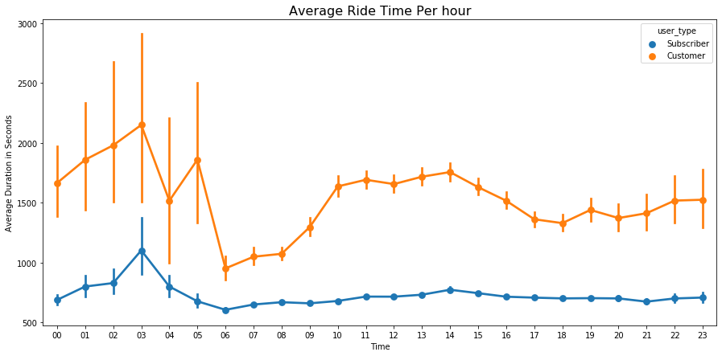

```python
#Visualizing the data in a point plot
plt.figure(figsize = (15, 7))
sb.pointplot(data = gobike, x = 'start_hr', y = 'duration_sec', hue = 'user_type');
plt.title('Average Ride Time Per hour', fontsize = 16);
plt.ylabel('Average Duration in Seconds');
plt.xlabel('Time');
```

**Exploration10**

- In this finalh analysis, we plot the average bike ride duration trends per hour in a day with different users (member and non_member).It shows that members are more tend to use the Gobike for the shorter ride during the day time, compared to the non-members who more choose the longer bike ride. Regarding the peak point at 3 o'clock in the early morning, it might be caused by no public transportation methods during that period.

> At the end of your report, make sure that you export the notebook as an html file from the `File > Download as... > HTML` menu. Make sure you keep track of where the exported file goes, so you can put it in the same folder as this notebook for project submission. Also, make sure you remove all of the quote-formatted guide notes like this one before you finish your report!